# Deconvolution of cell proporations in ATAC-seq samples

Maria Dimitriu & Leonard C. Steg

2022-06-20

## Loading packages

```r
suppressPackageStartupMessages({
  library(BayesPrism)
  library(stringr)
  library(epiwraps)
  library(GenomicRanges)
  library(SummarizedExperiment) # structure to contain data+annotation
  library(sechm) # for plotting heatmaps from SummarizedExperiment objects
  library(edgeR) # count-based differential analysis
  library(Rsubread) # for counting reads
  library(ggplot2) # for plotting
  library(patchwork)
  library(cowplot)
  library(viridis)
})
```

## Download scATAC data and metadata of scATAC data

The metadata includes the cell types to which the individual cells were annotated to.

```r
options(timeout = 10000)
download.file("http://krishna.gs.washington.edu/content/members/ajh24/mouse_atlas_data_release/matrices/atac_matrix.tfidf.qc_filtered.rds",
              destfile = "../data/scATAC/atac.matrix.filtered.rds")

download.file("http://krishna.gs.washington.edu/content/members/ajh24/mouse_atlas_data_release/metadata/cell_metadata.txt",
              "../data/scATAC/metadata.txt")
```

Reading in the data

```r
se <- readRDS("../data/scATAC/atac.matrix.filtered.rds")
metadata <- read.delim("../data/scATAC/metadata.txt")
```

### Preparation of single cell data

The metadata was subset based on the cell types of interest and then the SE was subset on the cells within the metadata. (While the naming of the SE might imply it is a SummerizedExperiment object, this is actually not true in this case)

```r
metadata <- metadata[metadata$tissue == "WholeBrain",]

names(table(metadata$cell_label[table(metadata$cell_label) > 50]))

metadata <- metadata[metadata$cell_label %in% names(table(metadata$cell_label))[table(metadata$cell_label) > 50],]
metadata <- metadata[metadata$cell_label != "Unknown" & metadata$cell_label != "Collisions",]

se <- se[,colnames(se) %in% metadata$cell]
identical(ncol(se), nrow(metadata))
dim(se)
dim(metadata)

se <- t(se)
```

BayesPrism requires 2 metadata columns. One is the cell type, which includes the broad cell type (like Glia, excitatory neurons and inhibitory neurons) and the other one is cell state, which describes the more detailed subtype of the cell (i.e. Astrocytes or microglia for Glia).

```r
metadata$cell_state <- "Inh. Neuron"
metadata[metadata$cell_label %in% c("Cerebellar granule cells", "Ex. neurons SCPN", "Ex. neurons CThPN", "Ex. neurons CPN"), "cell_state"] <- "Ex. Neuron"
metadata[metadata$cell_label %in% c("Astrocytes", "Microglia", "Oligodendrocytes"), "cell_state"] <- "Glia"
metadata[metadata$cell_label == "Endothelial II cells", "cell_state"] <- "Endothelial"

colnames(metadata)[11:12] <- c("cell.state","cell.type")
```

Save files

```r
saveRDS(se, "../data/scATAC/atac.matrix.filtered.brain.rds")
save(metadata, file = "../data/scATAC/metadata.Rdata")
```

Load files

```r
se <- readRDS("../data/scATAC/atac.matrix.filtered.brain.rds")
load("../data/scATAC/metadata.Rdata")
```

### Preparation of bulk data

The used regions for this analysis were the bins used in the scATAC data. Bulk data was quantified onto these regions using featureCounts

```r
regions <- GRanges(seqnames = gsub("\\_.*", "", colnames(se)),
                   IRanges(start = as.numeric(str_match(colnames(se), "\\_(.*?)\\_")[,2]), end = as.numeric(gsub(".*\\_", "", colnames(se)))))

bamfiles <- list.files("../data/merged/", pattern="ATAC_E1.\\.5.bam$", full=TRUE)
# we give the samples clean names:
names(bamfiles) <- gsub("\\.bam","",basename(bamfiles))
bamfiles
```

```
##                       ATAC_E11.5                       ATAC_E12.5
## "../data/merged//ATAC_E11.5.bam" "../data/merged//ATAC_E12.5.bam"
##                       ATAC_E13.5                       ATAC_E14.5
## "../data/merged//ATAC_E13.5.bam" "../data/merged//ATAC_E14.5.bam"
##                       ATAC_E15.5                       ATAC_E16.5
## "../data/merged//ATAC_E15.5.bam" "../data/merged//ATAC_E16.5.bam"
```

```r
# for counting, we need to convert our GRanges object to a data.frame with the following specifications:
anno <- cbind(name=as.character(regions), as.data.frame(regions))
anno$width <- NULL
colnames(anno) <- c("GeneID", "Chr", "Start", "End", "Strand")

fc <- featureCounts( files=bamfiles,    # the files in which we want to count reads
                     isPairedEnd=FALSE,
                     annot.ext=anno,    # the regions in which we want to count reads
                     readExtension3=50, # extend the reads by 50bp
                     nthreads=16         # multithreading (to speed up)
                    )
```

[output not shown]

[output cut: 25 more lines]

[output not shown]

```r
bulk <- t(fc$counts)
colnames(bulk) <- colnames(se)
```

## Running deconvolution

A prism object is created including single cell data, bulk data and the reference cell types and cell states.

```r
mat <- as.matrix(se)

myPrism <- new.prism(
  reference=mat,
  mixture=bulk,
  input.type="count.matrix",
  cell.type.labels = metadata$cell.type,
  cell.state.labels = metadata$cell.state,
  key=NULL,
  outlier.cut=0.01,
  outlier.fraction=0.1
)
```

```
## number of cells in each cell state
## cell.state.labels
##        SOM+ Interneurons     Endothelial II cells                Microglia
##                      148                      161                      191
##           Purkinje cells         Ex. neurons SCPN          Ex. neurons CPN
##                      195                      303                      439
##        Ex. neurons CThPN               Astrocytes         Oligodendrocytes
##                      543                      749                      969
##       Inhibitory neurons Cerebellar granule cells
##                     1205                     3004
## No tumor reference is speficied. Reference cell types are treated equally.
```

```
## Number of outlier genes filtered from mixture = 0
## Aligning reference and mixture...
## Nornalizing reference...
```

BayesPrism is run and saved.

```r
res <- run.prism(prism = myPrism, n.cores=16)
```

```
## Run Gibbs sampling...
## Current time:  2022-06-23 20:30:13
## Estimated time to complete:  37mins
## Estimated finishing time:  2022-06-23 21:06:34
## Start run...
```

```
## snowfall 1.84-6.1 initialized (using snow 0.4-4): parallel execution on 16 CPUs.
```

```
##
## Stopping cluster
```

```
## Update the reference matrix ...
```

```
## snowfall 1.84-6.1 initialized (using snow 0.4-4): parallel execution on 16 CPUs.
##
##
## Stopping cluster
```

```
## Run Gibbs sampling using updated reference ...
## Current time:  2022-06-23 20:49:18
## Estimated time to complete:  31mins
## Estimated finishing time:  2022-06-23 21:20:14
## Start run...
```

```
## snowfall 1.84-6.1 initialized (using snow 0.4-4): parallel execution on 16 CPUs.
##
##
## Stopping cluster
```

```r
save(res, file = "../output/scATAC/res.Prism.Rdata")
```

## Resulting cell proportions in the bulk data.

```r
load("../output/scATAC/res.Prism.Rdata")
theta <- get.fraction(bp=res,
            which.theta="final",
            state.or.type="type")
df <- data.frame(sort(rep(rownames(theta), 4)), rep(colnames(theta),6), round(as.vector(t(theta))*100, 2))
colnames(df) <- c("Timepoint", "CellType", "Percentage")

df$Timepoint <- gsub("\\.bam","",df$Timepoint)
df$Timepoint <- gsub("ATAC\\_","", df$Timepoint)
df
```

```
##    Timepoint    CellType Percentage
## 1      E11.5 Inh. Neuron      14.41
## 2      E11.5        Glia      10.53
## 3      E11.5 Endothelial       1.81
## 4      E11.5  Ex. Neuron      73.25
## 5      E12.5 Inh. Neuron      15.95
## 6      E12.5        Glia      10.99
## 7      E12.5 Endothelial       1.33
## 8      E12.5  Ex. Neuron      71.73
## 9      E13.5 Inh. Neuron      16.98
## 10     E13.5        Glia      11.42
## 11     E13.5 Endothelial       0.00
## 12     E13.5  Ex. Neuron      71.60
## 13     E14.5 Inh. Neuron      18.23
## 14     E14.5        Glia      11.48
## 15     E14.5 Endothelial       0.00
## 16     E14.5  Ex. Neuron      70.29
## 17     E15.5 Inh. Neuron      17.94
## 18     E15.5        Glia      11.74
## 19     E15.5 Endothelial       0.00
## 20     E15.5  Ex. Neuron      70.32
## 21     E16.5 Inh. Neuron      19.47
## 22     E16.5        Glia      11.91
## 23     E16.5 Endothelial       0.00
## 24     E16.5  Ex. Neuron      68.62
```

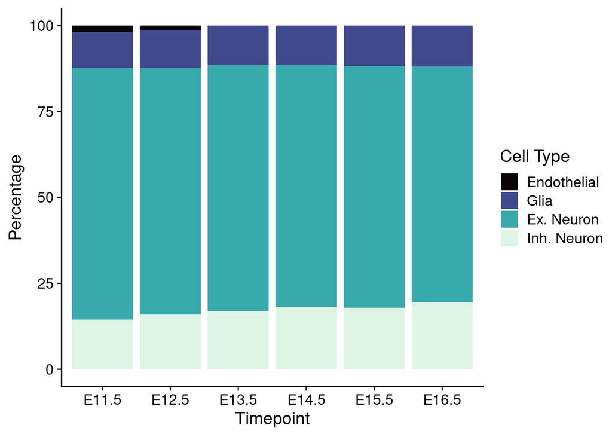

Figure 1: Cell proporations per bulk dataset. Proportions of endothelial cells, glia, inhibitory neurons and excitatory neurons are presented in percent.

```r
ggplot(df, aes(fill=factor(CellType, levels=c("Endothelial", "Glia","Ex. Neuron", "Inh. Neuron")), y=Percentage, x=Timepoint)) +
  geom_bar(position="stack", stat="identity") +
  theme_cowplot() +
  scale_fill_viridis(discrete = T, option = "G") +
  guides(fill=guide_legend(title="Cell Type"))
```

Using BayesPrismn we were able to extract the cell type proportions in our bulk ATAC datasets. We observed an increase of inhibitory neurons over time (from 14.4% to 19.5%), while the proportion of excitatory neurons decrease (from 73.3% to 68.6%). Glia cells are stably represented in all datasets with a proportion between 10.5% and 11.9%. Endothelial cells were only observed in the early timepoints, but only at low abundance (1.8%) and their proportion decreased to 0% from timepoint 13.5 on.